# Índices mundiales de Salud: Tasas de suicidio y consumo de alcohol en la población.

Rocío Pérez Aguayo

# Introducción

El presente trabajo busca explorar valores estadísticos de la población a nivel mundial en torno a la tasa de suicidio y consumo de alcohol, poniendo la lupa sobre los países con mayor o menor valor en estas tasas y prestando atención a las diferencias con filtro de género. Del mismo modo, se exploran posibles relaciones entre las variables.

# Datos utilizados

El siguiente informe se basó en una base de datos de un estudio descriptivo con indicadores de salud a nivel mundial, que posee mediciones desde el 2000 al 2018. La base de datos se encuentra contenida en el repositorio Kaggle, [disponible aquí.](https://www.kaggle.com/utkarshxy/who-worldhealth-statistics-2020-complete). Por otro lado, la base de datos procesada la puedes descargar desde mi Github [aquí](https://raw.githubusercontent.com/kala-hariz/bases_datos/main/world_health.csv)

Cada archivo contiene las siguientes columnas de datos en común:

• *Nombre del país*

• *Sexo*: Male, Female, Both Sexes.

• *Año*: Desde el 2000 al 2016/2018.

Los indicadores utilizados para realizar el análisis son los siguientes:

• *Tasas brutas de suicidio por 100 000 habitantes.*

• *Consumo total (registrado y no registrado) de alcohol per cápita de personas sobre 15 años.*

Dado que la base de datos consistía en múltiples archivos excel con los resultados de las variables separadas entre sí, se procedió a cargarlos al programa para luego realizarles una limpieza, buscando homogeneizar los nombres de variables, dandoles nombres más descriptivos, y excluyendo variables innecesarias para el análisis.

# Preguntas de interés para la exploración de datos

Las preguntas que conforman el desarrollo de este informe son las siguientes:

1. Mediciones estadísticas: media de consumo de alcohol y tasa de suicidio de hombres y mujeres en el mundo.
2. ¿Cuáles son los países con mayor y menor tasa de suicidio en 2015? ¿Cuáles son los países con mayor y menor tasa de suicidio femenino en 2015?
3. ¿Cuáles son los países con mayor y menor índice de consumo de alcohol en 2015?
4. ¿Existe una relación entre el consumo de alcohol y la tasa de suicidio a nivel mundial?

# Resultados

### Media de consumo de alcohol

La media de consumo de alcohol, agrupada por género, son las siguientes:

```
## # A tibble: 3 x 2
##   Sexes      media_consumo_alcohol
##   <chr>                      <dbl>
## 1 Both sexes                  6.10
## 2 Female                      2.64
## 3 Male                        9.73
```

A partir de esta tabla, observamos que si bien la media de consumo de alcohol es de 6.1, existe una diferencia importante entre el consumo de hombres y mujeres, en el que los hombres consumen en promedio 3.6 veces más que las mujeres.

### Media de tasas de suicidio

A nivel mundial, el mínimo de tasa de suicidio por país registrado es 0 y el máximo es 93.5.

La media de tasas de suicidio, separado por sexo, son las siguientes:

```
## # A tibble: 3 x 2
##   Sexes      media_tasa_suicidios
##   <chr>                     <dbl>
## 1 Both sexes                10.1
## 2 Female                     5.33
## 3 Male                      15.1
```

## Países con mayores y menores índices de consumo de alcohol para el 2015

A partir de la información mostrada, veamos cuáles son los países con mayor índice de consumo de alcohol, sin filtro por sexo:

```
## # A tibble: 10 x 5
##    Location           Period Sexes Alcohol Suicide
##    <chr>               <dbl> <chr>   <dbl>   <dbl>
##  1 Seychelles           2015 Male     28.6    16.5
##  2 Lithuania            2015 Male     24.7    61.7
##  3 Uganda               2015 Male     24.7    10.6
##  4 Czechia              2015 Male     22.0    22.6
##  5 Russian Federation   2015 Male     21.3    57.8
##  6 Latvia               2015 Male     20.7    37.4
##  7 Germany              2015 Male     20.1    19.9
##  8 Estonia              2015 Male     20.1    27.6
##  9 Burkina Faso         2015 Male     19.9    10.2
## 10 Luxembourg           2015 Male     19.8    21.4
```

Es importante notar que cuando no filtramos por sexo la totalidad de los países con mayor índice de consumo de alcohol son coronados por el consumo de alcohol de los hombres, algo que nos había sugerido los datos cuando observamos la media filtrada por género. Cuando observamos la tasa de suicidio correspondiente notamos que en su mayoría supera la media mundial, en algunos casos con creces. Observemos el caso para ambos sexos:

```
## # A tibble: 11 x 5
##    Location           Period Sexes      Alcohol Suicide
##    <chr>               <dbl> <chr>        <dbl>   <dbl>
##  1 Seychelles           2015 Both sexes    18.4     9.4
##  2 Lithuania            2015 Both sexes    15.4    34.9
##  3 Uganda               2015 Both sexes    15.1     9.9
##  4 Czechia              2015 Both sexes    14.2    13.7
##  5 Luxembourg           2015 Both sexes    13.2    14.7
##  6 Germany              2015 Both sexes    13.1    13.8
##  7 Slovenia             2015 Both sexes    12.7    21
##  8 France               2015 Both sexes    12.6    18
##  9 Latvia               2015 Both sexes    12.6    21.6
## 10 Ireland              2015 Both sexes    12.5    11.5
## 11 Russian Federation   2015 Both sexes    12.5    32.1
```

Para el caso de los países con menor tasa de consumo de alcohol, tenemos lo siguiente:

```
## # A tibble: 10 x 5
##    Location             Period Sexes      Alcohol Suicide
##    <chr>                 <dbl> <chr>        <dbl>   <dbl>
##  1 Kuwait                 2015 Both sexes   0.003     2.3
##  2 Somalia                2015 Both sexes   0.013     4.7
##  3 Bangladesh             2015 Both sexes   0.021     6.1
##  4 Libya                  2015 Both sexes   0.029     4.2
##  5 Mauritania             2015 Both sexes   0.033     4.3
##  6 Yemen                  2015 Both sexes   0.055     8.6
##  7 Saudi Arabia           2015 Both sexes   0.2       3.2
##  8 Afghanistan            2015 Both sexes   0.21      4.8
##  9 Syrian Arab Republic   2015 Both sexes   0.28      1.9
## 10 Pakistan               2015 Both sexes   0.29      2.9
```

Los datos nos muestran, en general, países del Medio Oriente cuya tasa de suicidio también es, a excepción de Yemen, significativamente menor a la media mundial.

Por último, exploremos el consumo de alcohol en mujeres:

```
## # A tibble: 10 x 5
##    Location   Period Sexes  Alcohol Suicide
##    <chr>       <dbl> <chr>    <dbl>   <dbl>
##  1 Seychelles   2015 Female    8.39     2.5
##  2 Lithuania    2015 Female    7.69    11.9
##  3 Czechia      2015 Female    6.91     5
##  4 Luxembourg   2015 Female    6.52     7.9
##  5 Germany      2015 Female    6.3      7.8
##  6 Ireland      2015 Female    6.13     4.5
##  7 Latvia       2015 Female    6.02     8.2
##  8 Slovenia     2015 Female    6.01     8.9
##  9 France       2015 Female    5.97    11.8
## 10 Uganda       2015 Female    5.92     9.3
```

Podemos observar que la tasa de mayor consumo de alcohol en mujeres corresponden a países de Europa, cuyos valores de tasa de suicidio son también, en general, mayores a la media mundial.

## Países con mayores y menores tasas de suicidio para el 2015

A partir de la información mostrada, veamos cuáles son los países con mayor tasa de suicidio, sin filtro de sexo:

```
## # A tibble: 10 x 5
##    Location           Period Sexes      Alcohol Suicide
##    <chr>               <dbl> <chr>        <dbl>   <dbl>
##  1 Lithuania            2015 Male         24.7     61.7
##  2 Russian Federation   2015 Male         21.3     57.8
##  3 Belarus              2015 Male         19.5     47
##  4 Guyana               2015 Male         11.8     43.4
##  5 Kazakhstan           2015 Male          7.73    42.5
##  6 Ukraine              2015 Male         17.0     42
##  7 Republic of Korea    2015 Male         15.2     39.9
##  8 Latvia               2015 Male         20.7     37.4
##  9 Suriname             2015 Male          9.25    36.3
## 10 Lithuania            2015 Both sexes   15.4     34.9
```

Nuevamente, observamos que las mayores tasas de suicidio son masculinas, solamente siendo Lithuania el país con tasas de suicidio máxima a nivel general. Además, podemos observar que, con excepción de Kazakhstan y Suriname, los valores máximos de suicidio se acompañan también de valores que superan la media de consumo de alcohol.

```
## # A tibble: 11 x 5
##    Location           Period Sexes      Alcohol Suicide
##    <chr>               <dbl> <chr>        <dbl>   <dbl>
##  1 Lithuania            2015 Both sexes   15.4     34.9
##  2 Russian Federation   2015 Both sexes   12.5     32.1
##  3 Guyana               2015 Both sexes    7.35    29.1
##  4 Republic of Korea    2015 Both sexes   10.0     28.3
##  5 Belarus              2015 Both sexes   12       26.3
##  6 Kazakhstan           2015 Both sexes    4.66    24.9
##  7 Suriname             2015 Both sexes    5.81    23.8
##  8 Ukraine              2015 Both sexes   10.2     23.1
##  9 Latvia               2015 Both sexes   12.6     21.6
## 10 Lesotho              2015 Both sexes    4.8     21
## 11 Slovenia             2015 Both sexes   12.7     21
```

Para el caso de las menores tasas de suicidio, obtenemos lo siguiente:

```
## # A tibble: 10 x 5
##    Location              Period Sexes      Alcohol Suicide
##    <chr>                  <dbl> <chr>        <dbl>   <dbl>
##  1 Barbados                2015 Both sexes   9.33      0.7
##  2 Antigua and Barbuda     2015 Both sexes   5.89      0.8
##  3 Grenada                 2015 Both sexes   9.07      1.1
##  4 Bahamas                 2015 Both sexes   4.55      1.8
##  5 Syrian Arab Republic    2015 Both sexes   0.28      1.9
##  6 Jamaica                 2015 Both sexes   4.19      2.1
##  7 Kuwait                  2015 Both sexes   0.003     2.3
##  8 Sao Tome and Principe   2015 Both sexes   7.19      2.3
##  9 Tajikistan              2015 Both sexes   3.11      2.5
## 10 Maldives                2015 Both sexes   2.07      2.6
```

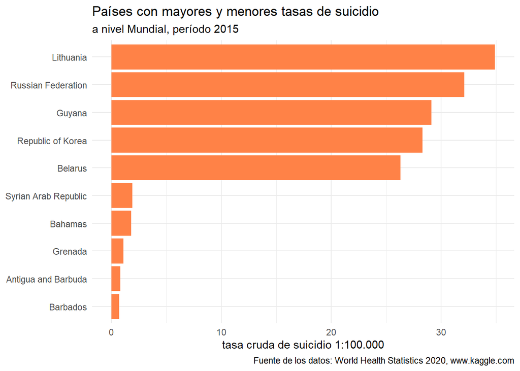

El gráfico impreso nos muestra los países con mayor y menor tasa de suicidio en el mundo, filtrado por sexo.

Observemos ahora los países con mayor tasa de suicidio femenino:

```
## # A tibble: 10 x 5
##    Location          Period Sexes  Alcohol Suicide
##    <chr>              <dbl> <chr>    <dbl>   <dbl>
##  1 Lesotho             2015 Female    1.67    24.1
##  2 Republic of Korea   2015 Female    4.97    16.5
##  3 India               2015 Female    1.88    14.9
##  4 Guyana              2015 Female    2.92    14.5
##  5 Belgium             2015 Female    5.62    13.4
##  6 Switzerland         2015 Female    5.64    12.3
##  7 Lithuania           2015 Female    7.69    11.9
##  8 France              2015 Female    5.97    11.8
##  9 Japan               2015 Female    3.84    11.8
## 10 Suriname            2015 Female    2.41    11.3
```

Para el caso de los países con menor tasa de suicidio femenino:

```
## # A tibble: 10 x 5
##    Location                         Period Sexes  Alcohol Suicide
##    <chr>                             <dbl> <chr>    <dbl>   <dbl>
##  1 Bahamas                            2015 Female   2.03      0.5
##  2 Barbados                           2015 Female   3.93      0.5
##  3 United Arab Emirates               2015 Female   0.8       0.7
##  4 Oman                               2015 Female   0.19      0.8
##  5 Qatar                              2015 Female   0.4       0.9
##  6 Syrian Arab Republic               2015 Female   0.072     0.9
##  7 Jamaica                            2015 Female   1.7       1
##  8 Saint Vincent and the Grenadines   2015 Female   3.41      1
##  9 Azerbaijan                         2015 Female   1.52      1.1
## 10 Grenada                            2015 Female   3.76      1.1
```

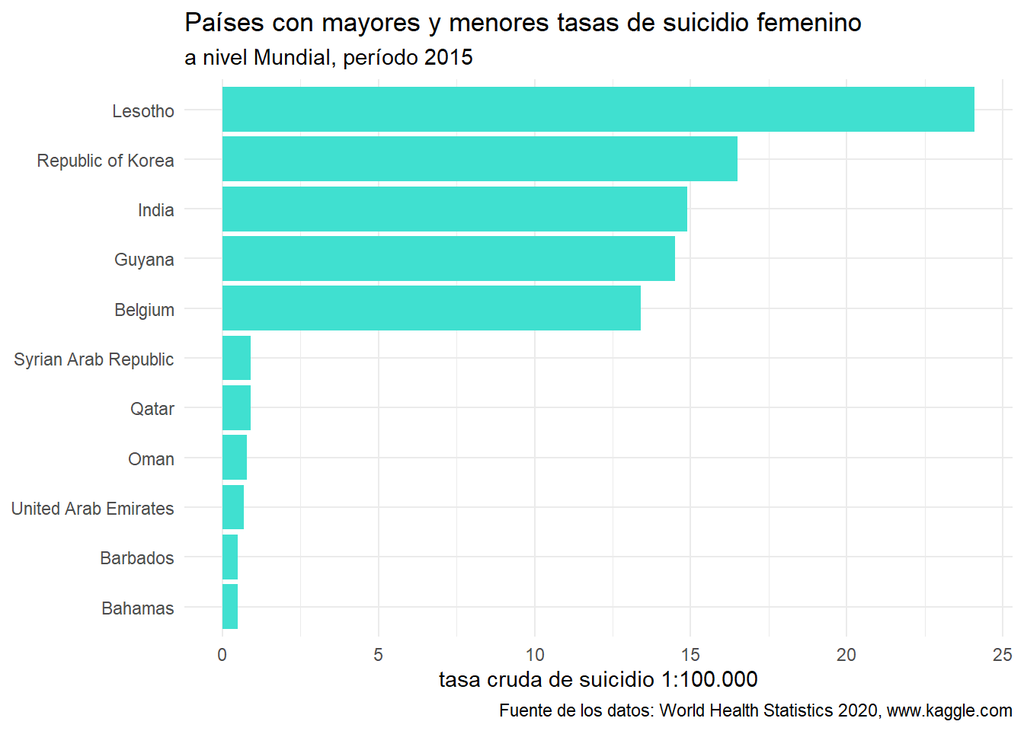

El gráfico impreso nos muestra los países con mayor y menor tasa de suicidio femenino en el mundo.

## Relaciones entre variables

### ¿Existe relación entre el uso de alcohol y el índice de suicidio a nivel mundial?

El siguiente gráfico busca explorar las posibles relaciones de regresión que existe entre el consumo de alcohol y la tasa de suicidio por país.

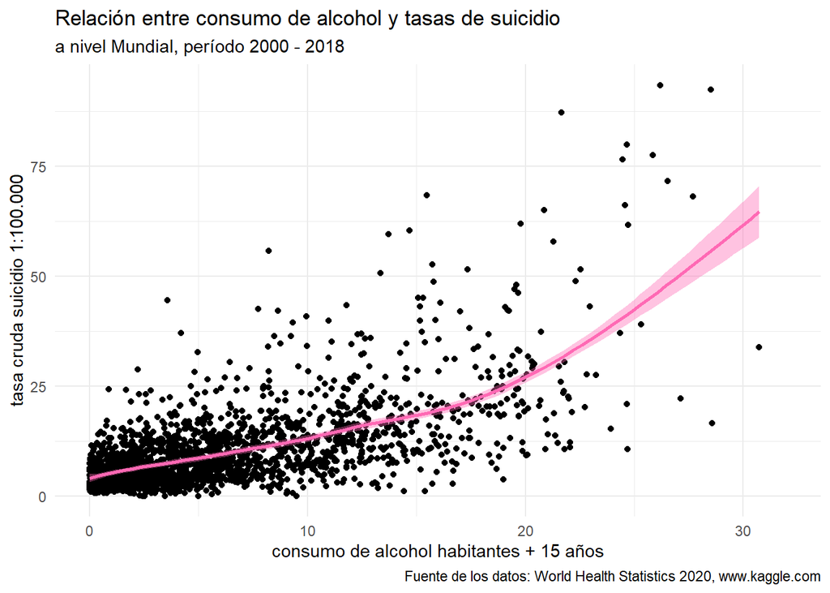

Podemos observar que existe una leve pendiente, sin embargo esta distribución es difusa y el error aumenta aún más a medida que se avanza en la tasa de suicidio y consumo de alcohol.

# Conclusiones

A través del informe pudimos observar las diferencias de consumo de alcohol y tasas de suicidio en el mundo. En general, podemos comentar que tanto la tasa de consumo de alcohol como la de suicidio tienen especificidad de género.

La información explorada sugiere una correlación, con la presencia de una leve pendiente positiva. Sin embargo, esta correlación se vuelve más difusa a medida que los numeros de las tasas aumentan.

Se sugiere la posibilidad de explorar los datos de acuerdo a filtros de género o continente, para ver si existen relaciones más limpias.